# MMM

### Linear Regression for MMM

```python
from sklearn.linear_model import LinearRegression
from sklearn.model_selection import cross_val_score, TimeSeriesSplit
import pandas as pd
```

```python
data = pd.read_csv(
    'MMM example.csv',
    parse_dates=['Date'],
    index_col='Date'
)
```

```python
data
```

| Date | TV | Radio | Banners | Sales |
| --- | --- | --- | --- | --- |
| 2018-01-07 | 13528.10 | 0.00 | 0.00 | 9779.80 |
| 2018-01-14 | 0.00 | 5349.65 | 2218.93 | 13245.19 |
| 2018-01-21 | 0.00 | 4235.86 | 2046.96 | 12022.66 |
| 2018-01-28 | 0.00 | 3562.21 | 0.00 | 8846.95 |
| 2018-02-04 | 0.00 | 0.00 | 2187.29 | 9797.07 |
| ... | ... | ... | ... | ... |
| 2021-10-03 | 0.00 | 0.00 | 1691.68 | 9030.17 |
| 2021-10-10 | 11543.58 | 4615.35 | 2518.88 | 15904.11 |
| 2021-10-17 | 0.00 | 4556.16 | 1919.19 | 12839.29 |
| 2021-10-24 | 0.00 | 0.00 | 1707.65 | 9063.45 |
| 2021-10-31 | 0.00 | 0.00 | 1863.31 | 7250.21 |

200 rows × 4 columns

```python
data.describe()
```

|  | TV | Radio | Banners | Sales |
| --- | --- | --- | --- | --- |
| count | 200.000000 | 200.000000 | 200.000000 | 200.000000 |
| mean | 2946.207650 | 2213.585050 | 1520.722550 | 10668.141500 |
| std | 4749.646908 | 2505.967886 | 870.764354 | 2700.706683 |
| min | 0.000000 | 0.000000 | 0.000000 | 4532.330000 |
| 25% | 0.000000 | 0.000000 | 1657.195000 | 8396.942500 |
| 50% | 0.000000 | 0.000000 | 1918.990000 | 10853.105000 |
| 75% | 7938.527500 | 4624.027500 | 2069.767500 | 12566.995000 |
| max | 13901.550000 | 7696.220000 | 2518.880000 | 17668.340000 |

```python
X = data.drop(columns=['Sales'])
y = data['Sales']
```

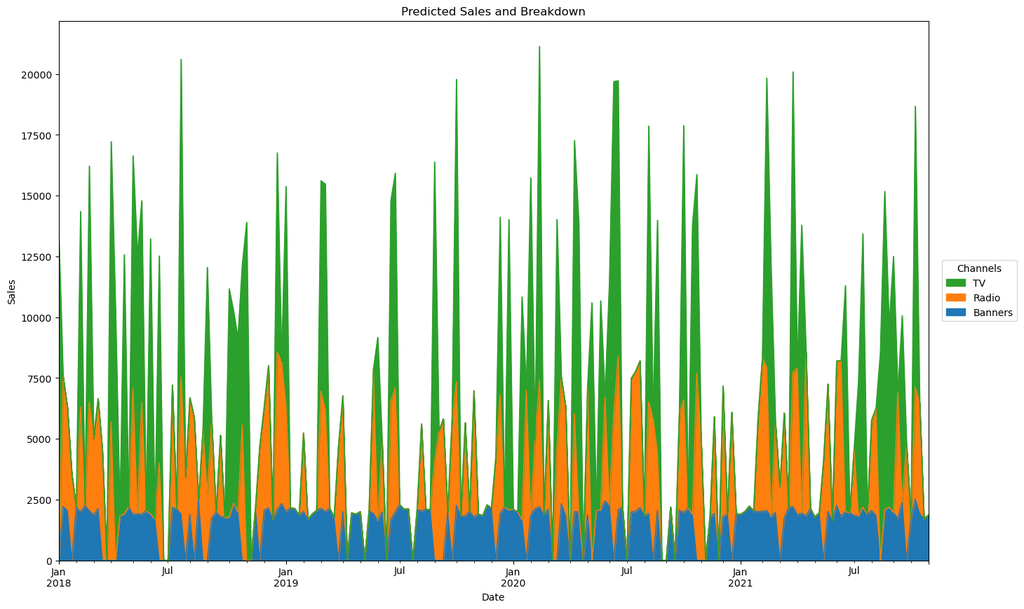

```python
ax = (data[['Banners', 'Radio', 'TV']]
      .plot.area(
          figsize=(16, 10),
          linewidth=1,
          title='Predicted Sales and Breakdown',
          ylabel='Sales',
          xlabel='Date')
     )

handles, labels = ax.get_legend_handles_labels()
ax.legend(
    handles[::-1], labels[::-1],
    title='Channels', loc="center left",
    bbox_to_anchor=(1.01, 0.5)
)
```

```python
import matplotlib.pyplot as plt
```

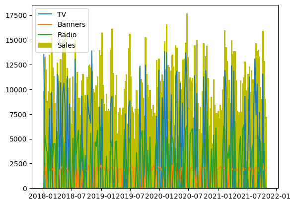

```python
plt.bar(y.index, y, label = 'Sales', width = 10, color = 'y')
plt.plot(X.TV, label = 'TV')
plt.plot(X.Banners, label = 'Banners')
plt.plot(X.Radio, label = 'Radio')
plt.legend()
plt.show()
```

```python
from statsmodels.tsa.seasonal import seasonal_decompose
```

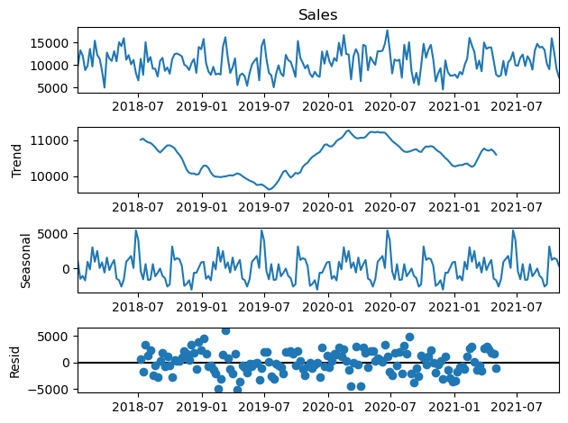

```python
decompose_data = seasonal_decompose(y, model="additive")
decompose_data.plot();
```

```python
lr = LinearRegression()

print(cross_val_score(lr, X, y, cv=TimeSeriesSplit()))
```

```
[0.69594303 0.69302285 0.66850729 0.78807363 0.73512387]
```

```python
lr.fit(X, y) # refit the model with the complete dataset

print('Coefficients:', lr.coef_)
print('Intercept:', lr.intercept_)
```

```
Coefficients: [0.35968382 0.48833246 1.2159193 ]
Intercept: 6678.396933606162
```

```python
print(lr.predict(([[11543.58, 4615.35, 2518.88]])))
```

```
[16147.01594158]
```

### Breaking down the sales

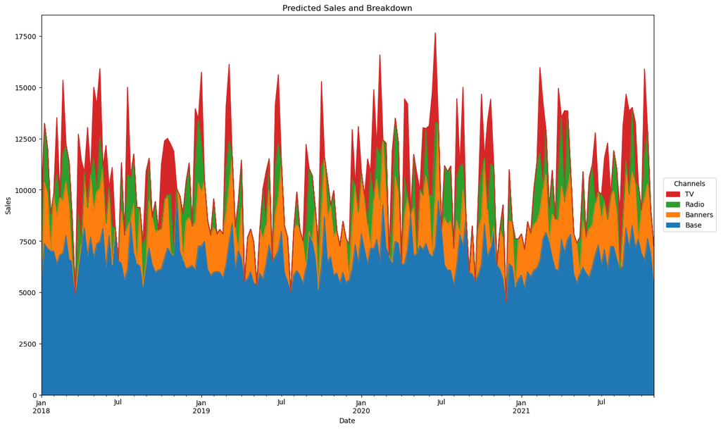

```python
weights = pd.Series(
    lr.coef_,
    index=X.columns
)

base = lr.intercept_

unadj_contributions = X.mul(weights).assign(Base=base)

adj_contributions = (unadj_contributions
                     .div(unadj_contributions.sum(axis=1), axis=0)
                     .mul(y, axis=0)
                    ) # contains all contributions for each day

ax = (adj_contributions[['Base', 'Banners', 'Radio', 'TV']]
      .plot.area(
          figsize=(16, 10),
          linewidth=1,
          title='Predicted Sales and Breakdown',
          ylabel='Sales',
          xlabel='Date')
     )

handles, labels = ax.get_legend_handles_labels()
ax.legend(
    handles[::-1], labels[::-1],
    title='Channels', loc="center left",
    bbox_to_anchor=(1.01, 0.5)
)
```

### ROI calculation

```python
sales_from_tv = adj_contributions['TV'].sum()
spendings_on_tv = data['TV'].sum()
tv_roi = sales_from_tv / spendings_on_tv
print(tv_roi)
```

```
0.3602450071355312
```

### Exponential function for saturation effect

```python
from sklearn.base import BaseEstimator, TransformerMixin
from sklearn.utils.validation import check_is_fitted, check_array

class ExponentialSaturation(BaseEstimator, TransformerMixin):
    def __init__(self, a=1.):
        self.a = a

    def fit(self, X, y=None):
        X = check_array(X)
        self._check_n_features(X, reset=True) # from BaseEstimator
        return self

    def transform(self, X):
        check_is_fitted(self)
        X = check_array(X)
        self._check_n_features(X, reset=False) # from BaseEstimator
        return 1 - np.exp(-self.a*X)
```

### Carry over function : goes two period only further.

(16, 0, 0, 0, 0, 4, 8, 0, 0, 0) > (16, 8, 4, 0, 0, 4, 10, 5, 2, 0)

```python
from scipy.signal import convolve2d
import numpy as np

class ExponentialCarryover(BaseEstimator, TransformerMixin):
    def __init__(self, strength=0.5, length=1):
        self.strength = strength
        self.length = length

    def fit(self, X, y=None):
        X = check_array(X)
        self._check_n_features(X, reset=True)
        self.sliding_window_ = (
            self.strength ** np.arange(self.length + 1)
        ).reshape(-1, 1)
        return self

    def transform(self, X: np.ndarray):
        check_is_fitted(self)
        X = check_array(X)
        self._check_n_features(X, reset=False)
        convolution = convolve2d(X, self.sliding_window_)
        if self.length > 0:
            convolution = convolution[: -self.length]
        return convolution
```

### Final Model

```python
from sklearn.compose import ColumnTransformer
from sklearn.pipeline import Pipeline
from sklearn.linear_model import LinearRegression

adstock = ColumnTransformer(
    [
     #### TV block ####
     ('tv_pipe', Pipeline([
                           ('carryover', ExponentialCarryover()),
                           ('saturation', ExponentialSaturation())
     ]), ['TV']),
     ('radio_pipe', Pipeline([
                           ('carryover', ExponentialCarryover()),
                           ('saturation', ExponentialSaturation())
     ]), ['Radio']),
     ('banners_pipe', Pipeline([
                           ('carryover', ExponentialCarryover()),
                           ('saturation', ExponentialSaturation())
     ]), ['Banners']),
    ],
    remainder='passthrough'
)

model = Pipeline([
                  ('adstock', adstock),
                  ('regression', LinearRegression())
])
```

```python
model.fit(X, y)

print(cross_val_score(model, X, y, cv=TimeSeriesSplit()).mean())
```

```
0.5527190073236667
```

### Hyper parameter tuning

optuna returns some errors at the moment, so use randomizedsearchCV for now

from optuna.integration import OptunaSearchCV from optuna.distributions import FloatDistribution, IntDistribution

print(cross_val_score(tuned_model, X, y, cv=TimeSeriesSplit()))

```python
from sklearn.model_selection import RandomizedSearchCV
from scipy.stats import uniform, randint

tuned_model = RandomizedSearchCV(
    estimator=model,
    param_distributions={
        'adstock__tv_pipe__carryover__strength': uniform(0, 1),
        'adstock__tv_pipe__carryover__length': randint(0, 6),
        'adstock__tv_pipe__saturation__a': uniform(0, 0.01),
        'adstock__radio_pipe__carryover__strength': uniform(0, 1),
        'adstock__radio_pipe__carryover__length': randint(0, 6),
        'adstock__radio_pipe__saturation__a': uniform(0, 0.01),
        'adstock__banners_pipe__carryover__strength': uniform(0, 1),
        'adstock__banners_pipe__carryover__length': randint(0, 6),
        'adstock__banners_pipe__saturation__a': uniform(0, 0.01),
    },
    n_iter=1000,
    cv=TimeSeriesSplit(),
    random_state=0
)
```

```python
print(cross_val_score(tuned_model, X, y, cv=TimeSeriesSplit()))
```

```
[0.78018088 0.93446412 0.90499445 0.9554231  0.91318173]
```

```python
tuned_model.fit(X, y)
```

```
RandomizedSearchCV(cv=TimeSeriesSplit(gap=0, max_train_size=None, n_splits=5, test_size=None),
                   estimator=Pipeline(steps=[('adstock',
                                              ColumnTransformer(remainder='passthrough',
                                                                transformers=[('tv_pipe',
                                                                               Pipeline(steps=[('carryover',
                                                                                                ExponentialCarryover()),
                                                                                               ('saturation',
                                                                                                ExponentialSaturation())]),
                                                                               ['TV']),
                                                                              ('radio_pipe',
                                                                               Pipeline(steps=[('carryover',
                                                                                                Exponentia...
                                        'adstock__tv_pipe__carryover__length': <scipy.stats._distn_infrastructure.rv_discrete_frozen object at 0x7fd5b5216970>,
                                        'adstock__tv_pipe__carryover__strength': <scipy.stats._distn_infrastructure.rv_continuous_frozen object at 0x7fd5b35e8fa0>,
                                        'adstock__tv_pipe__saturation__a': <scipy.stats._distn_infrastructure.rv_continuous_frozen object at 0x7fd5b52d90d0>},
                   random_state=0)
```

```python
print(tuned_model.best_params_)
print(tuned_model.best_estimator_.named_steps['regression'].coef_)
print(tuned_model.best_estimator_.named_steps['regression'].intercept_)
```

[output not shown]

### Forecasting

```python
X_new = pd.DataFrame({
    'TV': [10000, 0, 0],
    'Radio': [0, 3000, 0],
    'Banners': [1000, 1000, 1000]
})

tuned_model.predict(X_new)
```

```
array([12225.82566253, 12532.63109588,  8967.66170481])
```

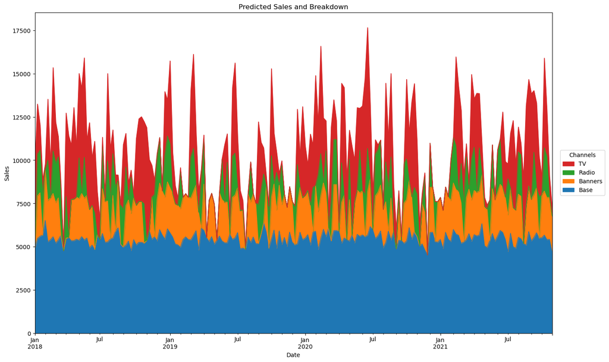

```python
adstock_data = pd.DataFrame(
    tuned_model.best_estimator_.named_steps['adstock'].transform(X),
    columns=X.columns,
    index=X.index
)

weights = pd.Series(
    tuned_model.best_estimator_.named_steps['regression'].coef_,
    index=X.columns
)

base = tuned_model.best_estimator_.named_steps['regression'].intercept_

unadj_contributions = adstock_data.mul(weights).assign(Base=base)
adj_contributions = (unadj_contributions
                     .div(unadj_contributions.sum(axis=1), axis=0)
                     .mul(y, axis=0)
                    )

ax = (adj_contributions[['Base', 'Banners', 'Radio', 'TV']]
      .plot.area(
          figsize=(16, 10),
          linewidth=1,
          title='Predicted Sales and Breakdown',
          ylabel='Sales',
          xlabel='Date'
      )
     )

handles, labels = ax.get_legend_handles_labels()
ax.legend(
    handles[::-1], labels[::-1],
    title='Channels', loc="center left",
    bbox_to_anchor=(1.01, 0.5)
)
```

### However, there are still some loose ends:

Feeding non-spending data into the model might improve it even more. Take the day of the week, the month, or the price of the product we want to sell, for example. Especially the price is an essential driver for sales: A regular iPhone offered for 10000 € would not generate many sales, while one for 100 € would be out of stock in a blink of an eye. Time features like the month can be interesting for seasonal products like fans or hot chocolate. Or special days like Christmas. Gather your thoughts, and make sure to add everything that can influence the sales!